# NYC Summer 2020 Bike Share Use

Himesh Buch

Notice that this is an [R Markdown](http://rmarkdown.rstudio.com) Notebook. When you execute code within the notebook, the results appear beneath the code.

You can execute chunks by clicking the *Run* button within the chunk or by placing your cursor inside it and pressing *Cmd+Shift+Enter* on a Mac or *Control+Shift+Enter* on Windows. You can go line by line with *Cmd+Enter* on a Mac or *Control+Enter* on Windows.

## Data

We will look at daily bike rentals from citibike, a bike share program in New York City, over the summer of 2019 and the summer of 2020.

```r
citibike <- read_csv("citibike.csv")
# Data aggregated from https://www.citibikenyc.com/system-data

# the code below will make sure that the days of the week go in order rather than alphabetically,
# and that year is treated not as a number but as a categorical variable
citibike <- citibike %>%
  mutate(day_of_the_week = factor(day_of_the_week, levels = c("Mon", "Tue", "Wed", "Thu", "Fri", "Sat", "Sun")),
         year = factor(year))

# A dataset with only 2019 data and one with only 2020 data

citibike2019 <- citibike %>%
  filter(year == "2019")

citibike2020 <- citibike %>%
  filter(year == "2020")

citibike %>% glimpse()
```

```
Rows: 184
Columns: 5
$ date            <date> 2019-06-01, 2019-06-02, 2019-06-03, 2019-06-04, 2019…
$ day             <dbl> 152, 153, 154, 155, 156, 157, 158, 159, 160, 161, 162…
$ year            <fct> 2019, 2019, 2019, 2019, 2019, 2019, 2019, 2019, 2019,…
$ day_of_the_week <fct> Sat, Sun, Mon, Tue, Wed, Thu, Fri, Sat, Sun, Mon, Tue…
$ rides           <dbl> 1350, 1109, 1371, 1604, 1413, 1481, 1547, 1209, 1338,…
```

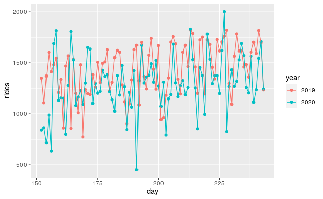

```r
citibike %>%
  ggplot(aes(day, rides, colour = year)) +
  geom_point() +
  geom_line()
```

From the plot, it looks like there might be a trend during the week, a linear increase during the summer, and lower use in 2020.

## 2020 model fit

Now we will look at 2020 only. We will include a `day` variable, which is day of the year, and also separate intercepts for the day of the week, using a hierarchical model. The argument `control = list(adapt_delta = 0.999)` is something to fix a problem that we won’t discuss for a few weeks.

```r
citi_hier_2020 <- stan_glmer(rides ~ day + (1 | day_of_the_week) , data = citibike2020, control = list(adapt_delta = 0.999))
```

Did this run long enough? We can use the `stableGR` approach. I’ll pick `day` as a parameter just to focus on something.

```r
citi_hier_2020 %>%
  as.array(pars = "day") %>%
  as.matrix %>%
  n.eff()
```

```
$n.eff
      se
3273.622

$converged
[1] FALSE

$n.target
  se
7510
```

Apparently not, since `converged` is `FALSE`. Let’s just go with 5000 iterations per chain. Notice the `cores = 4` argument to run the chains in parallel on the computer, which should be a little faster.

```r
citi_hier_2020 <- stan_glmer(rides ~ day + (1 | day_of_the_week), data = citibike2020, iter = 5000, control = list(adapt_delta = 0.999), cores = 4)
```

```
starting worker pid=641 on localhost:11302 at 19:12:45.430
starting worker pid=655 on localhost:11302 at 19:12:45.608
starting worker pid=669 on localhost:11302 at 19:12:45.785
starting worker pid=683 on localhost:11302 at 19:12:45.960
```

```r
citi_hier_2020 %>%
  as.array(pars = "day") %>%
  as.matrix %>%
  n.eff()
```

```
$n.eff
      se
8131.027

$converged
[1] TRUE

$n.target
NULL
```

Looks good. Looking at `shinystan` doesn’t raise any other convergence concerns. Remember to close the `shinystan` window when you are done.

```r
launch_shinystan(citi_hier_2020)
```

```
Hang on... preparing graphical posterior predictive checks for rstanarm model.
See help('shinystan', 'rstanarm') for how to disable this feature.

Launching ShinyStan interface... for large models this  may take some time.

Listening on http://127.0.0.1:7159
```

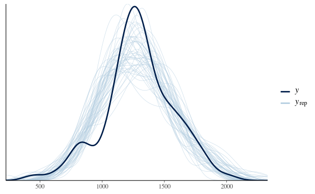

```r
pp_check(citi_hier_2020)
```

## Look at results

Let’s take a look at the distribution of the day of the week specific changes in the intercept. The `regex_pars = "Intercept.+day.of.the.week"` argument below is a pattern designed to pick out just the parameters we want—we’ll talk about it just a little later this semester. If you’re curious, `.` represents any character, and `.+` represents one or more of any character.

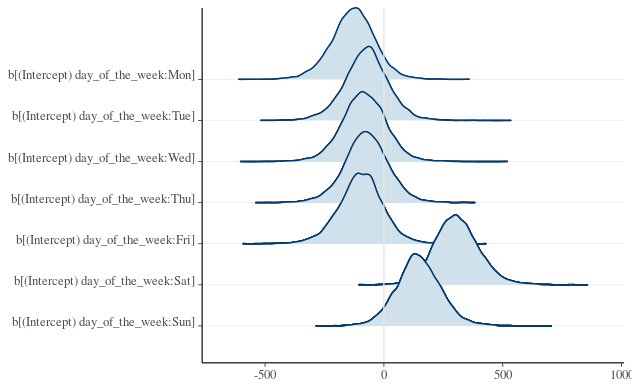

```r
plot(citi_hier_2020, plotfun = "areas_ridges", regex_pars = "Intercept.+day.of.the.week")
```

Pretty clearly Saturday and Sunday show a shift towards higher rides.

Let’s take a quick look at the numeric results. I want to use an interval of $(-50, 50)$ for the ROPE. Notice in the code it is written as `c(-50, 50)`.

```r
model_parameters(citi_hier_2020, ci = 0.9, rope_ci = 0.9, rope_range = c(-50, 50))
```

```
# Fixed effects

Parameter   | Median |            90% CI |     pd | % in ROPE |  Rhat |     ESS |                      Prior
------------------------------------------------------------------------------------------------------------
(Intercept) | 763.16 | [440.00, 1057.65] | 99.98% |        0% | 1.000 | 6215.85 | Normal (1292.04 +- 699.07)
day         |   2.69 | [  1.31,    4.13] | 99.87% |      100% | 1.000 | 8181.19 |     Normal (0.00 +- 26.18)
```

We can see the group effect by adding the argument `effects = "random"` to the function call.

```r
model_parameters(citi_hier_2020, ci = 0.9, rope_ci = 0.9, rope_range = c(-50, 50), effects = "random")
```

```
# Fixed effects

Parameter   | Median | 90% CI | pd | % in ROPE | Rhat | ESS |                      Prior
----------------------------------------------------------------------------------------
(Intercept) |        |        |    |           |      |     | Normal (1292.04 +- 699.07)
day         |        |        |    |           |      |     |     Normal (0.00 +- 26.18)

# Random effects Intercept: day_of_the_week

Parameter           |  Median |            90% CI |     pd | % in ROPE |  Rhat |     ESS |     Prior
----------------------------------------------------------------------------------------------------
day_of_the_week:Mon | -127.84 | [-283.60,  20.49] | 92.66% |    15.10% | 1.001 | 3479.59 | NA ( +- )
day_of_the_week:Tue |  -72.90 | [-226.12,  80.79] | 80.11% |    33.87% | 1.001 | 3583.30 | NA ( +- )
day_of_the_week:Wed |  -84.16 | [-234.92,  67.62] | 82.73% |    31.60% | 1.001 | 3645.96 | NA ( +- )
day_of_the_week:Thu |  -74.08 | [-226.60,  79.78] | 79.68% |    33.74% | 1.001 | 3671.47 | NA ( +- )
day_of_the_week:Fri |  -95.99 | [-256.21,  48.80] | 86.28% |    27.04% | 1.001 | 3670.58 | NA ( +- )
day_of_the_week:Sat |  303.79 | [ 157.55, 464.50] | 99.87% |        0% | 1.001 | 3837.53 | NA ( +- )
day_of_the_week:Sun |  144.32 | [  -5.73, 300.50] | 94.40% |    10.92% | 1.001 | 3702.39 | NA ( +- )

# Random effects SD/Cor: day_of_the_week

Parameter   |   Median |              90% CI |   pd | % in ROPE |  Rhat |     ESS |     Prior
---------------------------------------------------------------------------------------------
(Intercept) | 33516.65 | [6416.69, 85528.66] | 100% |        0% | 1.000 | 3278.23 | NA ( +- )
```

You can see that from the `pd` column that we are most confident that Saturday, Sunday, and Monday are to one side of zero.

## A direct probability calculation

It will help to know the names of the parameters that R is using. One way to do that is by using the `names()` function.

```r
citi_hier_2020 %>%
  as.data.frame() %>%
  names()
```

```
 [1] "(Intercept)"
 [2] "day"
 [3] "b[(Intercept) day_of_the_week:Mon]"
 [4] "b[(Intercept) day_of_the_week:Tue]"
 [5] "b[(Intercept) day_of_the_week:Wed]"
 [6] "b[(Intercept) day_of_the_week:Thu]"
 [7] "b[(Intercept) day_of_the_week:Fri]"
 [8] "b[(Intercept) day_of_the_week:Sat]"
 [9] "b[(Intercept) day_of_the_week:Sun]"
[10] "sigma"
[11] "Sigma[day_of_the_week:(Intercept),(Intercept)]"
```

What is the probability that summer Sundays in 2020 had fewer rides than Mondays? We need to be able to write out the condition, and because the names are not legal R variable names we have to use back ticks.

```r
citi_hier_2020 %>%
  as.data.frame() %$%
  mean(`b[(Intercept) day_of_the_week:Sun]` < `b[(Intercept) day_of_the_week:Mon]`)
```

```
[1] 0.0011
```